# Problem Set 09

Lauren Sullivan, BIO_SC 8002_01

Due April 29, 2022

## MacArthur’s Warblers

### Background

```r
###############
#
# 09 PROBLEM SET
#
# DUE:        April 29, 2022
#
# CREATED BY: Lauren Sullivan
# FILES:      "warblers.csv"
#
###############


########### setup
rm(list=ls())


library(tidyverse)
library(vegan)  #for standardization, distance matrices and nmds
library(goeveg)


########### data
birds <- read_csv("../data/warblers.csv")
```

MacArthur was trying to understand a set of 5 species of warblers in Maine. People believed that these species were an “exception” to the concept of the niche, which at the time stated that species needed to differ in their resource use in order to coexist. These species were seen as an exception because they all seemed nearly identical in where they lived and what they ate. However in his paper, MacArthur determined that these species utilized different parts of trees for foraging, and that they ate different resources at different times and thus were able to coexist.

In this homework, we will focus on the observations he made of the different warbler species in different areas of trees. MacArthur studied 16 sites within trees, which are labeled in Figure 1. There are 6 heights (1-6) on the tree, which I flipped so the tallest height is 6 and the shortest height is 1. There are also three “zones” including bare zones at the base of the trunk (B) that are often covered in lichen, middle zones (M) with old needles, and terminal zones (T) with new needles or buds. We will be using the data on the right side of these tree figures that indicates the number of observations of each of the 5 studied warblers within each of the 16 sites (I have converted the data into # of observations, not % of total observations).Our goal will be to figure out what we can learn from this data using multivariate statistics - which was not a method used frequently in the 50’s.

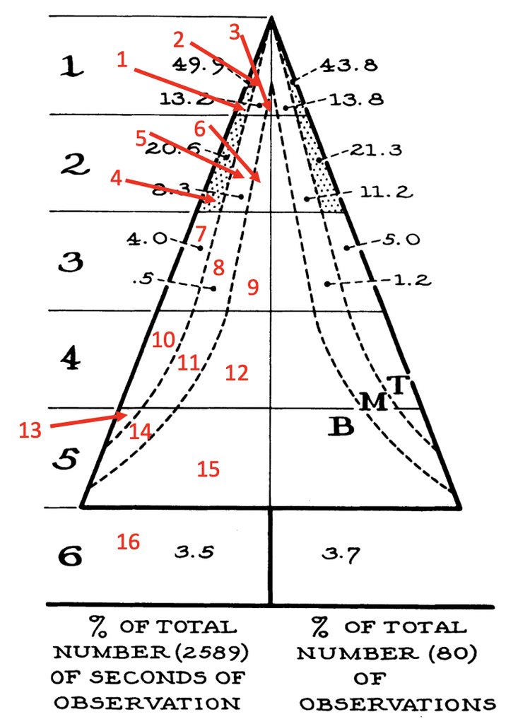

Figure adapted from MacArthur 1958 showing the 16 sites where he studied bird abundance.

```r
knitr::include_graphics('../images/treeplots.png')
```

**Q1** Let’s start by examining the data. Look at the data and explain how the dataset is structured. What are the rows? What are the columns? Pay special attention to the species data. How is it organized?

```r
birds
```

```
## # A tibble: 16 × 8
##     site cape_may_warbler myrtle_warbler black_th…¹ black…² baybr…³ zone  height
##    <dbl>            <dbl>          <dbl>      <dbl>   <dbl>   <dbl> <chr>  <dbl>
##  1     1            35.0           31.0      20.0      24.7  20.1   term…      6
##  2     2            11.0            9.99      8.04     13     9.92  mid        6
##  3     3             0              2.10      0         3.9   0.968 base       6
##  4     4            17.0           27.9      31.0      10.4  19.1   term…      5
##  5     5             8.96          16.0      16.1      13    20.1   mid        5
##  6     6             0              5.00      1.80      6.4  12.1   base       5
##  7     7             4             21.8      30.0      13    31.9   term…      4
##  8     8             0.96          22.1      19.0      10.4  46.0   mid        4
##  9     9             0             20.0       5.08      2.6  30.0   base       4
## 10    10             0              8.94     11.0       1.3  14.0   term…      3
## 11    11             0              7.10      7.05      1.3  17.9   mid        3
## 12    12             0             23.9       7.05      0    16.9   base       3
## 13    13             0              0         3.77      0     0     term…      2
## 14    14             0              2.10      0.984     0     0.968 mid        2
## 15    15             0             31.0       3.12      0     1.94  base       2
## 16    16             2.96          33.9       0         0     0     under      1
## # … with abbreviated variable names ¹black_throated_green_warbler,
## #   ²blackburnian_warbler, ³baybreasted_warbler
```

```r
# Each row is a site on the tree, so you have 16 sites, thus 16
#   rows.  You have columns for various environmental information
#   such as site name, and the type of zone each site is.  And the
#   species data are organized where each species is a column, and the
#   number of observations of each species can be found in the cells
#   within each site.
```

**Q2** Let’s visualize the data. Create barplots for each of the warblers in each zone and see if you can visually see a difference betwen the birds and where they spend most of their time. Does it look like the birds use different habitats?

```r
birds.g <- pivot_longer(birds, cols = cape_may_warbler:baybreasted_warbler, names_to = "warbler", values_to  = "observations")

birds.g
```

```
## # A tibble: 80 × 5
##     site zone     height warbler                      observations
##    <dbl> <chr>     <dbl> <chr>                               <dbl>
##  1     1 terminal      6 cape_may_warbler                    35.0
##  2     1 terminal      6 myrtle_warbler                      31.0
##  3     1 terminal      6 black_throated_green_warbler        20.0
##  4     1 terminal      6 blackburnian_warbler                24.7
##  5     1 terminal      6 baybreasted_warbler                 20.1
##  6     2 mid           6 cape_may_warbler                    11.0
##  7     2 mid           6 myrtle_warbler                       9.99
##  8     2 mid           6 black_throated_green_warbler         8.04
##  9     2 mid           6 blackburnian_warbler                13
## 10     2 mid           6 baybreasted_warbler                  9.92
## # … with 70 more rows
```

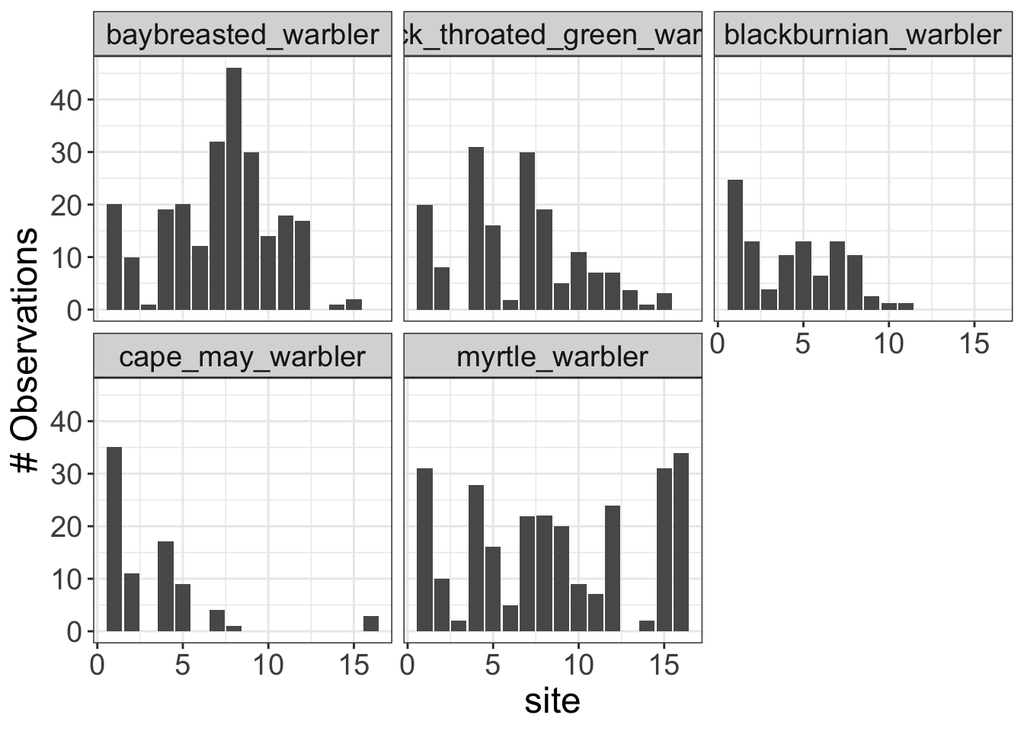

```r
ggplot(birds.g, aes(x = site, y = observations))+
  geom_bar(stat="identity")+
  facet_wrap(~warbler)+
  theme_bw()+
  theme(text = element_text(size=18))+
  labs(x = "site", y = "# Observations")
```

```r
# It is possible the birds use different habitat types based on
#   the bar chart.
```

## Distance Matrices

**Q3** To understand how different these 16 sites are within the tree, we need to create distance matrices to represent the dissimilarity between each site. The first step to this is standardizing the data. Create three standardized data matrices using `decostand()`, standardizing for site total, site max, and presence/absence. Compare these outcomes.

```r
birds.sub <- birds[,c(2:6)]

birds.tot <- decostand(birds.sub, "total")
birds.tot
```

```
##    cape_may_warbler myrtle_warbler black_throated_green_warbler
## 1       0.267750711      0.2371397                   0.15288688
## 2       0.212340360      0.1922219                   0.15456224
## 3       0.000000000      0.3017785                   0.00000000
## 4       0.161620760      0.2644169                   0.29399044
## 5       0.120818220      0.2163266                   0.21671768
## 6       0.000000000      0.1975021                   0.07130153
## 7       0.039688446      0.2165898                   0.29778241
## 8       0.009750548      0.2243845                   0.19322337
## 9       0.000000000      0.3465326                   0.08814147
## 10      0.000000000      0.2535587                   0.31157489
## 11      0.000000000      0.2128533                   0.21138455
## 12      0.000000000      0.4993845                   0.14714658
## 13      0.000000000      0.0000000                   1.00000000
## 14      0.000000000      0.5187377                   0.24260355
```

[output cut: 19 more lines]

```r
birds.max <- decostand(birds.sub, "max")
birds.max
```

```
##    cape_may_warbler myrtle_warbler black_throated_green_warbler
## 1        1.00000000      0.9147287                   0.64550265
## 2        0.31506849      0.2945736                   0.25925926
## 3        0.00000000      0.0620155                   0.00000000
## 4        0.48630137      0.8217054                   1.00000000
## 5        0.25570776      0.4728682                   0.51851852
## 6        0.00000000      0.1472868                   0.05820106
## 7        0.11415525      0.6434109                   0.96825397
## 8        0.02739726      0.6511628                   0.61375661
## 9        0.00000000      0.5891473                   0.16402116
## 10       0.00000000      0.2635659                   0.35449735
## 11       0.00000000      0.2093023                   0.22751323
## 12       0.00000000      0.7054264                   0.22751323
## 13       0.00000000      0.0000000                   0.12169312
## 14       0.00000000      0.0620155                   0.03174603
```

[output cut: 19 more lines]

```r
birds.pa <- decostand(birds.sub, "pa")
birds.pa
```

```
##    cape_may_warbler myrtle_warbler black_throated_green_warbler
## 1                 1              1                            1
## 2                 1              1                            1
## 3                 0              1                            0
## 4                 1              1                            1
## 5                 1              1                            1
## 6                 0              1                            1
## 7                 1              1                            1
## 8                 1              1                            1
## 9                 0              1                            1
## 10                0              1                            1
## 11                0              1                            1
## 12                0              1                            1
## 13                0              0                            1
## 14                0              1                            1
```

[output cut: 19 more lines]

```r
# The matrices are fairly similar, except the maximum values
#   are really different with the different standardizations.
#   And the presence/absence standardization just gives 1's
#   and 0's.
```

**Q4** Now let’s create a distances matrix for our data. It does not make sense to use either Euclidean or Manhattan distance because these points do not have a physical distance between the two. So similar to other community abundance datasets, let’s try creating a Bray-Curtis distance matrix, as well as a Jaccard distance matrix to really upweight rare events. Make sure to use the datset that is standardized by site totals for the Bray-Curtis distance matrix, and the dataset that is standardized by presence/absense for the Jaccard distance matrix.

```r
birds.b <- vegdist(birds.tot, "bray")
birds.b
```

```
##            1         2         3         4         5         6         7
## 2  0.1003282
## 3  0.4352794 0.4188986
## 4  0.1962280 0.2116232 0.4981003
## 5  0.1811911 0.1662663 0.4695380 0.1661655
## 6  0.3889737 0.2956011 0.4107024 0.4512245 0.2850589
## 7  0.3083646 0.2937029 0.5155817 0.1697594 0.1274366 0.2852570
## 8  0.3538642 0.3469973 0.5311435 0.2926697 0.2042253 0.1585548 0.1578534
## 9  0.4761596 0.4837233 0.5143041 0.4210352 0.3796124 0.2078781 0.3332405
## 10 0.4196278 0.4255161 0.5707376 0.2342580 0.2592498 0.2963300 0.1318132
## 11 0.4418092 0.4234112 0.6093379 0.3554643 0.2659513 0.2139868 0.2198425
## 12 0.4622308 0.4697945 0.5593804 0.4071064 0.3656836 0.3777274 0.3193117
## 13 0.8471131 0.8454378 1.0000000 0.7060096 0.7832823 0.9286985 0.7022176
## 14 0.4564905 0.4623788 0.5593804 0.3116494 0.3282969 0.4925376 0.3021479
## 15 0.6228614 0.6677792 0.6445718 0.5955842 0.6436745 0.6775468 0.6434113
## 16 0.6826152 0.7275330 0.6982215 0.6553381 0.7034283 0.8024979 0.7437218
##            8         9        10        11        12        13        14
## 2
## 3
## 4
## 5
## 6
## 7
## 8
## 9  0.1753871
## 10 0.1475257 0.2234334
## 11 0.0879450 0.1397879 0.1408957
## 12 0.2750000 0.2118570 0.2458258 0.2865311
## 13 0.8067766 0.9118585 0.6884251 0.7886154 0.8528534
## 14 0.3437334 0.3266672 0.2651790 0.3371033 0.1148102 0.7573964
## 15 0.6356166 0.5134685 0.6064424 0.6471478 0.3606167 0.9136507 0.3412634
## 16 0.7658650 0.6534674 0.7464413 0.7871467 0.5006155 1.0000000 0.4812623
##           15
## 2
## 3
## 4
## 5
## 6
## 7
## 8
## 9
## 10
## 11
## 12
## 13
## 14
## 15
## 16 0.1399989
```

```r
birds.j <- vegdist(birds.pa, "jaccard")
birds.j
```

```
##            1         2         3         4         5         6         7
## 2  0.0000000
## 3  0.4000000 0.4000000
## 4  0.0000000 0.0000000 0.4000000
## 5  0.0000000 0.0000000 0.4000000 0.0000000
## 6  0.2000000 0.2000000 0.2500000 0.2000000 0.2000000
## 7  0.0000000 0.0000000 0.4000000 0.0000000 0.0000000 0.2000000
## 8  0.0000000 0.0000000 0.4000000 0.0000000 0.0000000 0.2000000 0.0000000
## 9  0.2000000 0.2000000 0.2500000 0.2000000 0.2000000 0.0000000 0.2000000
## 10 0.2000000 0.2000000 0.2500000 0.2000000 0.2000000 0.0000000 0.2000000
## 11 0.2000000 0.2000000 0.2500000 0.2000000 0.2000000 0.0000000 0.2000000
## 12 0.4000000 0.4000000 0.5000000 0.4000000 0.4000000 0.2500000 0.4000000
## 13 0.8000000 0.8000000 1.0000000 0.8000000 0.8000000 0.7500000 0.8000000
## 14 0.4000000 0.4000000 0.5000000 0.4000000 0.4000000 0.2500000 0.4000000
## 15 0.4000000 0.4000000 0.5000000 0.4000000 0.4000000 0.2500000 0.4000000
## 16 0.6000000 0.6000000 0.7500000 0.6000000 0.6000000 0.8000000 0.6000000
##            8         9        10        11        12        13        14
## 2
## 3
## 4
## 5
## 6
## 7
## 8
## 9  0.2000000
## 10 0.2000000 0.0000000
## 11 0.2000000 0.0000000 0.0000000
## 12 0.4000000 0.2500000 0.2500000 0.2500000
## 13 0.8000000 0.7500000 0.7500000 0.7500000 0.6666667
## 14 0.4000000 0.2500000 0.2500000 0.2500000 0.0000000 0.6666667
## 15 0.4000000 0.2500000 0.2500000 0.2500000 0.0000000 0.6666667 0.0000000
## 16 0.6000000 0.8000000 0.8000000 0.8000000 0.7500000 1.0000000 0.7500000
##           15
## 2
## 3
## 4
## 5
## 6
## 7
## 8
## 9
## 10
## 11
## 12
## 13
## 14
## 15
## 16 0.7500000
```

**Q5** Using both of your distance matrices, what is the distance between sites 1 and 7, sites 3 and 4, sites 13 and 16? Explain what you see between the two distance measures for those between sites 1 and 7.

```r
#                   bray      jaccard
#sites 1 and 7      0.308     0
#sites 3 and 4      0.498     0.4
#sites 13 and 16    1         1


# Sites 1 and 7 have are slightly dissimilar with Bray-Curtis
#   because their abundances are slightly different. However,
#   when you use Jaccard, you are converting to 1's and 0's. So
#   while sites 1 and 7 have abundance differences, they have all
#   the same species in them, and thus their dissimilarity is 0.
#   This demonstrates how it changes things to upweight rare species.
```

**Q6** Using the standardized data by site totals and the `metaMDS()` function with Bray-Curtis distance, create three metaMDS objects, with dimensions `k=1`, `k=2`, and `k=3`. Create the plot that looks at stress for those three dimensions, and describe the patterns and stress you see for each metaMDS object. What is the approximate stress for each dimension? Based on these results, which dimension would you choose and why?

```r
birds.mds1 <- metaMDS(birds.tot, k = 1, distance = 'bray', autotransform = F,
expand = F)
```

```
## *** Best solution was not repeated -- monoMDS stopping criteria:
##     20: scale factor of the gradient < sfgrmin
```